# Project2

# Train/Test Split

```r
summary(df)
```

```
##       age                 job           marital
##  Min.   :17.00   admin.     :9937   divorced: 4302
##  1st Qu.:32.00   blue-collar:8560   married :23180
##  Median :38.00   technician :6378   single  :10760
##  Mean   :39.86   services   :3716
##  3rd Qu.:47.00   management :2728
##  Max.   :98.00   retired    :1577
##                  (Other)    :5346
##                education        default      housing      loan
##  basic.4y           : 4002   no     :30485   no :17665   no :32283
##  basic.6y           : 2204   unknown: 7757   yes:20577   yes: 5959
##  basic.9y           : 5856
##  high.school        : 9243
##  illiterate         :   18
##  professional.course: 5098
##  university.degree  :11821
##       contact          month       day_of_week    duration
##  cellular :24438   may    :12794   fri:7224    Min.   :   0.0
##  telephone:13804   jul    : 6630   mon:7927    1st Qu.: 102.0
##                    aug    : 5820   thu:8011    Median : 180.0
##                    jun    : 4846   tue:7478    Mean   : 258.2
##                    nov    : 3897   wed:7602    3rd Qu.: 319.0
##                    apr    : 2436               Max.   :4918.0
##                    (Other): 1819
##     campaign          pdays          previous           poutcome
##  Min.   : 1.000   Min.   :  0.0   Min.   :0.00   failure    : 3935
##  1st Qu.: 1.000   1st Qu.:999.0   1st Qu.:0.00   nonexistent:33064
##  Median : 2.000   Median :999.0   Median :0.00   success    : 1243
##  Mean   : 2.567   Mean   :963.5   Mean   :0.17
##  3rd Qu.: 3.000   3rd Qu.:999.0   3rd Qu.:0.00
##  Max.   :43.000   Max.   :999.0   Max.   :7.00
##
##   emp_var_rate     cons_price_idx  cons_conf_idx      euribor3m
##  Min.   :-3.4000   Min.   :92.20   Min.   :-50.80   Min.   :0.634
##  1st Qu.:-1.8000   1st Qu.:93.08   1st Qu.:-42.70   1st Qu.:1.344
##  Median : 1.1000   Median :93.44   Median :-41.80   Median :4.857
##  Mean   : 0.0828   Mean   :93.57   Mean   :-40.54   Mean   :3.623
##  3rd Qu.: 1.4000   3rd Qu.:93.99   3rd Qu.:-36.40   3rd Qu.:4.961
##  Max.   : 1.4000   Max.   :94.77   Max.   :-26.90   Max.   :5.045
##
##   nr_employed    Age_Grp     prevly_Cntctd duration_group    y
##  Min.   :4964   17-31:8740   No :36876     0-5min :27843   no :33984
##  1st Qu.:5099   32-37:9893   Yes: 1366     5-10min: 7189   yes: 4258
##  Median :5191   38-47:9834                 10+ min: 3210
##  Mean   :5167   47-55:6598
##  3rd Qu.:5228   >55  :3177
##  Max.   :5228
##
```

```r
#38242 obs. of 24 variables

set.seed(1234)
df_yes <- df %>% filter(y=='yes')
df_No <- df %>% filter(y=='no')

num_rows_yes <- nrow(df_yes) #4,258
num_rows_no <- nrow(df_No) #33,984

train_idx_yes <- sample(1:num_rows_yes, 0.8 * num_rows_yes)
train_yes <- df_yes[train_idx_yes, ]
test_yes <- df_yes[-train_idx_yes, ]

nrow(train_yes) #3,406
```

```
## [1] 3406
```

```r
nrow(test_yes)  #852
```

```
## [1] 852
```

```r
train_idx_no <- sample(1:num_rows_no, 0.8 * num_rows_no)
train_no <- df_No[train_idx_no, ]
test_no <- df_No[-train_idx_no, ]
nrow(train_no) #27,187
```

```
## [1] 27187
```

```r
nrow(test_no)  #6797
```

```
## [1] 6797
```

```r
train <- rbind(train_yes, train_no)
test <- rbind(test_yes, test_no)
nrow(train) #30,593
```

```
## [1] 30593
```

```r
nrow(test) #7,649
```

```
## [1] 7649
```

```r
nrow(train %>% filter(y=='yes')) #3,406
```

```
## [1] 3406
```

```r
nrow(test %>% filter(y=='yes'))  #852
```

```
## [1] 852
```

```r
summary(train)
```

```
##       age                 job           marital                    education
##  Min.   :17.00   admin.     :7949   divorced: 3461   basic.4y           :3123
##  1st Qu.:32.00   blue-collar:6846   married :18542   basic.6y           :1758
##  Median :38.00   technician :5157   single  : 8590   basic.9y           :4694
##  Mean   :39.83   services   :2956                    high.school        :7444
##  3rd Qu.:47.00   management :2191                    illiterate         :  12
##  Max.   :98.00   retired    :1252                    professional.course:4092
##                  (Other)    :4242                    university.degree  :9470
##     default      housing      loan            contact          month
##  no     :24427   no :14200   no :25850   cellular :19613   may    :10156
##  unknown: 6166   yes:16393   yes: 4743   telephone:10980   jul    : 5340
##                                                            aug    : 4713
##                                                            jun    : 3884
##                                                            nov    : 3119
##                                                            apr    : 1943
##                                                            (Other): 1438
##  day_of_week    duration         campaign          pdays          previous
##  fri:5807    Min.   :   0.0   Min.   : 1.000   Min.   :  0.0   Min.   :0.00
##  mon:6307    1st Qu.: 103.0   1st Qu.: 1.000   1st Qu.:999.0   1st Qu.:0.00
##  thu:6392    Median : 179.0   Median : 2.000   Median :999.0   Median :0.00
##  tue:5993    Mean   : 257.3   Mean   : 2.571   Mean   :963.6   Mean   :0.17
##  wed:6094    3rd Qu.: 318.0   3rd Qu.: 3.000   3rd Qu.:999.0   3rd Qu.:0.00
##              Max.   :4199.0   Max.   :43.000   Max.   :999.0   Max.   :7.00
##
##         poutcome      emp_var_rate      cons_price_idx  cons_conf_idx
##  failure    : 3159   Min.   :-3.40000   Min.   :92.20   Min.   :-50.80
##  nonexistent:26452   1st Qu.:-1.80000   1st Qu.:93.08   1st Qu.:-42.70
##  success    :  982   Median : 1.10000   Median :93.44   Median :-41.80
##                      Mean   : 0.08542   Mean   :93.57   Mean   :-40.53
##                      3rd Qu.: 1.40000   3rd Qu.:93.99   3rd Qu.:-36.40
##                      Max.   : 1.40000   Max.   :94.77   Max.   :-26.90
##
##    euribor3m      nr_employed    Age_Grp     prevly_Cntctd duration_group
##  Min.   :0.634   Min.   :4964   17-31:6981   No :29503     0-5min :22312
##  1st Qu.:1.344   1st Qu.:5099   32-37:7969   Yes: 1090     5-10min: 5756
##  Median :4.857   Median :5191   38-47:7853                 10+ min: 2525
##  Mean   :3.625   Mean   :5168   47-55:5273
##  3rd Qu.:4.961   3rd Qu.:5228   >55  :2517
##  Max.   :5.045   Max.   :5228
##
##    y
##  no :27187
##  yes: 3406
##
##
##
##
##
```

```r
#30593 obs. of 24 variables
#write.csv(train, "data/train.csv", row.names = FALSE)
#write.csv(test, "data/test.csv", row.names = FALSE)
```

# Simple Logistic Model

```r
# Run Initial Logistic Regression
#Simple regression model
simple.log<-glm(y~.,family="binomial",data=train)
summary(simple.log)
```

```
##
## Call:
## glm(formula = y ~ ., family = "binomial", data = train)
##
## Deviance Residuals:
##     Min       1Q   Median       3Q      Max
## -4.5608  -0.2992  -0.1624  -0.1226   3.2477
##
## Coefficients:
##                                Estimate Std. Error z value Pr(>|z|)
## (Intercept)                  -2.223e+02  5.036e+01  -4.415 1.01e-05 ***
## age                           5.815e-03  7.219e-03   0.806 0.420486
## jobblue-collar               -2.436e-01  9.381e-02  -2.596 0.009422 **
## jobentrepreneur              -1.341e-01  1.446e-01  -0.928 0.353604
## jobhousemaid                 -1.386e-01  1.755e-01  -0.790 0.429541
## jobmanagement                -8.405e-02  1.002e-01  -0.839 0.401492
## jobretired                    5.598e-02  1.424e-01   0.393 0.694245
## jobself-employed             -1.335e-01  1.334e-01  -1.000 0.317109
## jobservices                  -2.259e-01  1.010e-01  -2.237 0.025293 *
## jobstudent                    2.154e-01  1.413e-01   1.525 0.127372
## jobtechnician                 3.799e-02  8.197e-02   0.463 0.643065
## jobunemployed                -7.248e-02  1.574e-01  -0.460 0.645255
## maritalmarried               -1.636e-02  8.011e-02  -0.204 0.838184
## maritalsingle                 1.179e-02  9.190e-02   0.128 0.897935
## educationbasic.6y             2.053e-01  1.371e-01   1.497 0.134281
## educationbasic.9y             2.475e-02  1.099e-01   0.225 0.821782
## educationhigh.school          6.886e-02  1.079e-01   0.638 0.523458
## educationilliterate           1.864e+00  8.450e-01   2.206 0.027403 *
## educationprofessional.course  1.060e-01  1.186e-01   0.894 0.371490
## educationuniversity.degree    1.883e-01  1.088e-01   1.732 0.083355 .
## defaultunknown               -2.945e-01  7.873e-02  -3.740 0.000184 ***
## housingyes                   -5.811e-03  4.794e-02  -0.121 0.903512
## loanyes                      -2.902e-02  6.697e-02  -0.433 0.664705
## contacttelephone             -6.742e-01  9.203e-02  -7.326 2.37e-13 ***
## monthaug                      8.414e-01  1.446e-01   5.818 5.96e-09 ***
## monthdec                     -4.116e-02  2.669e-01  -0.154 0.877428
## monthjul                      1.327e-01  1.138e-01   1.166 0.243486
## monthjun                     -5.261e-01  1.525e-01  -3.449 0.000562 ***
## monthmar                      2.260e+00  1.730e-01  13.062  < 2e-16 ***
## monthmay                     -4.213e-01  9.954e-02  -4.233 2.31e-05 ***
```

[output cut: 20 more lines]

```
## Age_Grp47-55                 -2.579e-01  1.774e-01  -1.454 0.145967
## Age_Grp>55                   -2.183e-01  2.491e-01  -0.877 0.380654
## prevly_CntctdYes             -1.387e+01  2.074e+01  -0.669 0.503489
## duration_group5-10min         1.135e+00  7.127e-02  15.930  < 2e-16 ***
## duration_group10+ min         2.075e+00  1.323e-01  15.689  < 2e-16 ***
## ---
## Signif. codes:  0 '***' 0.001 '**' 0.01 '*' 0.05 '.' 0.1 ' ' 1
##
## (Dispersion parameter for binomial family taken to be 1)
##
##     Null deviance: 21372  on 30592  degrees of freedom
## Residual deviance: 12329  on 30538  degrees of freedom
## AIC: 12439
##
## Number of Fisher Scoring iterations: 6
```

```r
exp(cbind("Odds ratio" = coef(simple.log), confint.default(simple.log, level = 0.95)))
```

```
##                                Odds ratio         2.5 %       97.5 %
## (Intercept)                  2.755572e-97 3.757741e-140 2.020676e-54
## age                          1.005832e+00  9.917014e-01 1.020164e+00
## jobblue-collar               7.838373e-01  6.521962e-01 9.420492e-01
## jobentrepreneur              8.744637e-01  6.586404e-01 1.161008e+00
## jobhousemaid                 8.705519e-01  6.171960e-01 1.227909e+00
## jobmanagement                9.193843e-01  7.554739e-01 1.118857e+00
## jobretired                   1.057577e+00  8.000080e-01 1.398073e+00
## jobself-employed             8.750683e-01  6.737419e-01 1.136555e+00
## jobservices                  7.977859e-01  6.545150e-01 9.724181e-01
## jobstudent                   1.240405e+00  9.403251e-01 1.636249e+00
## jobtechnician                1.038717e+00  8.845530e-01 1.219750e+00
## jobunemployed                9.300874e-01  6.831499e-01 1.266285e+00
## maritalmarried               9.837732e-01  8.408233e-01 1.151026e+00
## maritalsingle                1.011858e+00  8.450698e-01 1.211565e+00
## educationbasic.6y            1.227928e+00  9.385468e-01 1.606533e+00
## educationbasic.9y            1.025059e+00  8.264621e-01 1.271377e+00
## educationhigh.school         1.071284e+00  8.670414e-01 1.323638e+00
## educationilliterate          6.449192e+00  1.230831e+00 3.379188e+01
## educationprofessional.course 1.111788e+00  8.812320e-01 1.402663e+00
## educationuniversity.degree   1.207250e+00  9.754599e-01 1.494117e+00
## defaultunknown               7.449007e-01  6.383800e-01 8.691954e-01
## housingyes                   9.942054e-01  9.050452e-01 1.092149e+00
## loanyes                      9.713926e-01  8.519102e-01 1.107633e+00
## contacttelephone             5.095418e-01  4.254416e-01 6.102666e-01
## monthaug                     2.319545e+00  1.747032e+00 3.079673e+00
## monthdec                     9.596751e-01  5.687990e-01 1.619160e+00
## monthjul                     1.141908e+00  9.136581e-01 1.427179e+00
## monthjun                     5.909148e-01  4.382230e-01 7.968096e-01
## monthmar                     9.582710e+00  6.826786e+00 1.345118e+01
## monthmay                     6.561732e-01  5.398673e-01 7.975355e-01
## monthnov                     6.098405e-01  4.616810e-01 8.055463e-01
## monthoct                     1.167882e+00  8.152245e-01 1.673096e+00
## monthsep                     1.285756e+00  8.417352e-01 1.963999e+00
## day_of_weekmon               9.084426e-01  7.814141e-01 1.056121e+00
## day_of_weekthu               1.047842e+00  9.049554e-01 1.213290e+00
## day_of_weektue               1.070218e+00  9.207758e-01 1.243914e+00
## day_of_weekwed               1.097114e+00  9.437215e-01 1.275439e+00
## duration                     1.002482e+00  1.002172e+00 1.002792e+00
## campaign                     9.664782e-01  9.420461e-01 9.915439e-01
## pdays                        9.853384e-01  9.456437e-01 1.026699e+00
## previous                     9.621262e-01  8.328027e-01 1.111532e+00
## poutcomenonexistent          1.521587e+00  1.214123e+00 1.906913e+00
## poutcomesuccess              3.121867e+00  1.828929e+00 5.328830e+00
## emp_var_rate                 1.643902e-01  1.174062e-01 2.301765e-01
## cons_price_idx               9.419212e+00  5.217318e+00 1.700520e+01
## cons_conf_idx                1.031513e+00  1.012934e+00 1.050432e+00
## euribor3m                    1.487657e+00  1.105461e+00 2.001992e+00
## nr_employed                  1.004443e+00  9.972402e-01 1.011699e+00
## Age_Grp32-37                 8.136361e-01  6.936764e-01 9.543409e-01
## Age_Grp38-47                 6.906583e-01  5.454750e-01 8.744835e-01
## Age_Grp47-55                 7.726490e-01  5.457288e-01 1.093925e+00
## Age_Grp>55                   8.038517e-01  4.933828e-01 1.309688e+00
## prevly_CntctdYes             9.425133e-07  2.094494e-24 4.241268e+11
## duration_group5-10min        3.112525e+00  2.706723e+00 3.579168e+00
## duration_group10+ min        7.968439e+00  6.148455e+00 1.032715e+01
```

```r
vif(simple.log)
```

```
##                        GVIF Df GVIF^(1/(2*Df))
## age               13.821928  1        3.717785
## job                7.636632 10        1.106994
## marital            1.484682  2        1.103846
## education          3.306893  6        1.104803
## default            1.145764  1        1.070403
## housing            1.017146  1        1.008537
## loan               1.008311  1        1.004147
## contact            2.542053  1        1.594382
## month             70.173060  9        1.266383
## day_of_week        1.069342  4        1.008416
## duration           4.838922  1        2.199755
## campaign           1.057760  1        1.028475
## pdays          71073.146963  1      266.595474
## previous           4.756874  1        2.181026
## poutcome          28.653541  2        2.313634
## emp_var_rate     156.519117  1       12.510760
## cons_price_idx    69.869415  1        8.358793
## cons_conf_idx      5.321632  1        2.306866
## euribor3m        138.853417  1       11.783608
## nr_employed      175.816806  1       13.259593
## Age_Grp           17.119294  4        1.426217
## prevly_Cntctd  70425.497503  1      265.378028
## duration_group     5.251183  2        1.513785
```

Remove either pdays or prevly_Cntctd - think prevly_Cntcted will be more useful, remove pdays and re-run.

```r
train_simple <- train %>% dplyr::select(-pdays)
#Check vifs again
simple.log<-glm(y~.,family="binomial",data=train_simple)
summary(simple.log)
```

```
##
## Call:
## glm(formula = y ~ ., family = "binomial", data = train_simple)
##
## Deviance Residuals:
##     Min       1Q   Median       3Q      Max
## -4.5593  -0.2993  -0.1624  -0.1226   3.2471
##
## Coefficients:
##                                Estimate Std. Error z value Pr(>|z|)
## (Intercept)                  -2.375e+02  4.553e+01  -5.216 1.83e-07 ***
## age                           5.858e-03  7.218e-03   0.812 0.416988
## jobblue-collar               -2.422e-01  9.378e-02  -2.583 0.009799 **
## jobentrepreneur              -1.336e-01  1.446e-01  -0.924 0.355656
## jobhousemaid                 -1.379e-01  1.755e-01  -0.786 0.431987
## jobmanagement                -8.348e-02  1.002e-01  -0.833 0.404646
## jobretired                    5.796e-02  1.423e-01   0.407 0.683836
## jobself-employed             -1.323e-01  1.334e-01  -0.992 0.321208
## jobservices                  -2.240e-01  1.009e-01  -2.219 0.026458 *
## jobstudent                    2.167e-01  1.413e-01   1.534 0.125148
## jobtechnician                 3.829e-02  8.197e-02   0.467 0.640433
## jobunemployed                -7.072e-02  1.574e-01  -0.449 0.653190
## maritalmarried               -1.668e-02  8.010e-02  -0.208 0.835065
## maritalsingle                 1.152e-02  9.189e-02   0.125 0.900241
## educationbasic.6y             2.053e-01  1.371e-01   1.498 0.134262
## educationbasic.9y             2.398e-02  1.099e-01   0.218 0.827248
## educationhigh.school          6.940e-02  1.079e-01   0.643 0.520145
## educationilliterate           1.862e+00  8.452e-01   2.203 0.027573 *
## educationprofessional.course  1.064e-01  1.186e-01   0.897 0.369580
## educationuniversity.degree    1.899e-01  1.087e-01   1.747 0.080704 .
## defaultunknown               -2.940e-01  7.872e-02  -3.735 0.000188 ***
## housingyes                   -5.333e-03  4.793e-02  -0.111 0.911406
## loanyes                      -2.815e-02  6.694e-02  -0.421 0.674081
## contacttelephone             -6.737e-01  9.203e-02  -7.321 2.47e-13 ***
## monthaug                      8.414e-01  1.446e-01   5.817 5.98e-09 ***
## monthdec                     -4.464e-02  2.669e-01  -0.167 0.867171
## monthjul                      1.309e-01  1.138e-01   1.151 0.249938
## monthjun                     -5.278e-01  1.525e-01  -3.461 0.000539 ***
## monthmar                      2.260e+00  1.730e-01  13.063  < 2e-16 ***
## monthmay                     -4.219e-01  9.954e-02  -4.238 2.25e-05 ***
```

[output cut: 19 more lines]

```
## Age_Grp47-55                 -2.582e-01  1.774e-01  -1.455 0.145572
## Age_Grp>55                   -2.192e-01  2.490e-01  -0.880 0.378641
## prevly_CntctdYes              7.248e-01  2.574e-01   2.816 0.004867 **
## duration_group5-10min         1.135e+00  7.128e-02  15.927  < 2e-16 ***
## duration_group10+ min         2.076e+00  1.323e-01  15.690  < 2e-16 ***
## ---
## Signif. codes:  0 '***' 0.001 '**' 0.01 '*' 0.05 '.' 0.1 ' ' 1
##
## (Dispersion parameter for binomial family taken to be 1)
##
##     Null deviance: 21372  on 30592  degrees of freedom
## Residual deviance: 12329  on 30539  degrees of freedom
## AIC: 12437
##
## Number of Fisher Scoring iterations: 6
```

```r
#exp(cbind("Odds ratio" = coef(simple.log), confint.default(simple.log, level = 0.95)))
vif(simple.log)
```

```
##                      GVIF Df GVIF^(1/(2*Df))
## age             13.821213  1        3.717689
## job              7.623054 10        1.106895
## marital          1.484784  2        1.103865
## education        3.301390  6        1.104650
## default          1.145646  1        1.070348
## housing          1.016929  1        1.008429
## loan             1.007988  1        1.003986
## contact          2.541775  1        1.594294
## month           70.151837  9        1.266362
## day_of_week      1.069201  4        1.008399
## duration         4.839426  1        2.199870
## campaign         1.057798  1        1.028493
## previous         4.604360  1        2.145777
## poutcome        24.503123  2        2.224874
## emp_var_rate   156.298337  1       12.501933
## cons_price_idx  69.874867  1        8.359119
## cons_conf_idx    5.323534  1        2.307279
## euribor3m      138.744098  1       11.778968
## nr_employed    175.716197  1       13.255799
## Age_Grp         17.116671  4        1.426190
## prevly_Cntctd   10.849640  1        3.293879
## duration_group   5.251773  2        1.513828
```

VIFs are still high for euribor3m and nr_employed, and model shows nr_employed as significant. Remove nr_employed and emp_var_rate and see if things change

```r
train_simple_2 <- train_simple %>% dplyr::select(-nr_employed, -emp_var_rate )
simple.log<-glm(y~.,family="binomial",data=train_simple_2)
summary(simple.log)
```

```
##
## Call:
## glm(formula = y ~ ., family = "binomial", data = train_simple_2)
##
## Deviance Residuals:
##     Min       1Q   Median       3Q      Max
## -4.4487  -0.3011  -0.1734  -0.1205   3.3117
##
## Coefficients:
##                                Estimate Std. Error z value Pr(>|z|)
## (Intercept)                  -4.602e+01  5.270e+00  -8.733  < 2e-16 ***
## age                           7.291e-03  7.223e-03   1.009 0.312808
## jobblue-collar               -2.783e-01  9.360e-02  -2.974 0.002943 **
## jobentrepreneur              -1.376e-01  1.438e-01  -0.957 0.338654
## jobhousemaid                 -1.609e-01  1.757e-01  -0.916 0.359648
## jobmanagement                -8.610e-02  9.972e-02  -0.863 0.387911
## jobretired                    6.410e-02  1.419e-01   0.452 0.651439
## jobself-employed             -1.256e-01  1.329e-01  -0.945 0.344854
## jobservices                  -2.295e-01  1.004e-01  -2.286 0.022234 *
## jobstudent                    2.494e-01  1.408e-01   1.771 0.076584 .
## jobtechnician                 2.409e-02  8.135e-02   0.296 0.767103
## jobunemployed                -7.861e-02  1.560e-01  -0.504 0.614275
## maritalmarried               -4.442e-03  7.974e-02  -0.056 0.955580
## maritalsingle                 2.461e-02  9.143e-02   0.269 0.787803
## educationbasic.6y             1.961e-01  1.368e-01   1.433 0.151799
## educationbasic.9y             2.684e-02  1.097e-01   0.245 0.806752
## educationhigh.school          4.574e-02  1.078e-01   0.424 0.671243
## educationilliterate           1.779e+00  8.447e-01   2.106 0.035171 *
## educationprofessional.course  7.647e-02  1.186e-01   0.645 0.519135
## educationuniversity.degree    1.859e-01  1.086e-01   1.711 0.087002 .
## defaultunknown               -3.222e-01  7.862e-02  -4.099 4.15e-05 ***
## housingyes                   -4.285e-03  4.767e-02  -0.090 0.928376
## loanyes                      -4.179e-02  6.660e-02  -0.627 0.530343
## contacttelephone             -3.683e-01  8.232e-02  -4.473 7.70e-06 ***
## monthaug                      1.854e-01  1.211e-01   1.531 0.125811
## monthdec                      1.522e-02  2.520e-01   0.060 0.951840
## monthjul                      3.201e-01  1.119e-01   2.860 0.004233 **
## monthjun                      3.806e-01  1.089e-01   3.495 0.000475 ***
## monthmar                      1.723e+00  1.440e-01  11.969  < 2e-16 ***
## monthmay                     -6.451e-01  8.961e-02  -7.198 6.09e-13 ***
```

[output cut: 17 more lines]

```
## Age_Grp47-55                 -2.822e-01  1.772e-01  -1.593 0.111141
## Age_Grp>55                   -2.453e-01  2.485e-01  -0.987 0.323533
## prevly_CntctdYes              8.528e-01  2.536e-01   3.363 0.000772 ***
## duration_group5-10min         1.102e+00  7.053e-02  15.624  < 2e-16 ***
## duration_group10+ min         1.996e+00  1.318e-01  15.145  < 2e-16 ***
## ---
## Signif. codes:  0 '***' 0.001 '**' 0.01 '*' 0.05 '.' 0.1 ' ' 1
##
## (Dispersion parameter for binomial family taken to be 1)
##
##     Null deviance: 21372  on 30592  degrees of freedom
## Residual deviance: 12483  on 30541  degrees of freedom
## AIC: 12587
##
## Number of Fisher Scoring iterations: 6
```

```r
#exp(cbind("Odds ratio" = coef(simple.log), confint.default(simple.log, level = 0.95)))
vif(simple.log)
```

```
##                     GVIF Df GVIF^(1/(2*Df))
## age            13.872114  1        3.724529
## job             7.614780 10        1.106835
## marital         1.480832  2        1.103129
## education       3.301974  6        1.104666
## default         1.139451  1        1.067451
## housing         1.015359  1        1.007650
## loan            1.007564  1        1.003775
## contact         2.011504  1        1.418275
## month           5.563261  9        1.100037
## day_of_week     1.056779  4        1.006927
## duration        4.826047  1        2.196827
## campaign        1.053851  1        1.026573
## previous        4.601227  1        2.145047
## poutcome       23.920157  2        2.211521
## cons_price_idx  2.619965  1        1.618630
## cons_conf_idx   2.367099  1        1.538538
## euribor3m       3.096350  1        1.759645
## Age_Grp        17.174524  4        1.426792
## prevly_Cntctd  10.681927  1        3.268322
## duration_group  5.170012  2        1.507901
```

```r
train_simple_3 <- train_simple_2 %>% dplyr::select(-age)
#Check model again
simple.log<-glm(y~.,family="binomial",data=train_simple_3)
summary(simple.log)
```

```
##
## Call:
## glm(formula = y ~ ., family = "binomial", data = train_simple_3)
##
## Deviance Residuals:
##     Min       1Q   Median       3Q      Max
## -4.4520  -0.3014  -0.1734  -0.1205   3.3154
##
## Coefficients:
##                                Estimate Std. Error z value Pr(>|z|)
## (Intercept)                  -4.603e+01  5.271e+00  -8.733  < 2e-16 ***
## jobblue-collar               -2.818e-01  9.354e-02  -3.012 0.002593 **
## jobentrepreneur              -1.384e-01  1.439e-01  -0.962 0.336075
## jobhousemaid                 -1.518e-01  1.752e-01  -0.867 0.386197
## jobmanagement                -8.534e-02  9.973e-02  -0.856 0.392144
## jobretired                    1.121e-01  1.333e-01   0.841 0.400441
## jobself-employed             -1.243e-01  1.329e-01  -0.935 0.349623
## jobservices                  -2.315e-01  1.004e-01  -2.305 0.021153 *
## jobstudent                    2.225e-01  1.384e-01   1.608 0.107799
## jobtechnician                 2.418e-02  8.136e-02   0.297 0.766348
## jobunemployed                -8.215e-02  1.560e-01  -0.527 0.598528
## maritalmarried               -1.056e-02  7.946e-02  -0.133 0.894267
## maritalsingle                 1.297e-02  9.066e-02   0.143 0.886232
## educationbasic.6y             1.872e-01  1.364e-01   1.373 0.169852
## educationbasic.9y             1.737e-02  1.092e-01   0.159 0.873620
## educationhigh.school          3.362e-02  1.070e-01   0.314 0.753263
## educationilliterate           1.754e+00  8.479e-01   2.069 0.038571 *
## educationprofessional.course  6.392e-02  1.178e-01   0.542 0.587497
## educationuniversity.degree    1.740e-01  1.078e-01   1.614 0.106513
## defaultunknown               -3.217e-01  7.859e-02  -4.094 4.24e-05 ***
## housingyes                   -4.493e-03  4.767e-02  -0.094 0.924914
## loanyes                      -4.107e-02  6.659e-02  -0.617 0.537383
## contacttelephone             -3.704e-01  8.230e-02  -4.500 6.78e-06 ***
## monthaug                      1.851e-01  1.211e-01   1.529 0.126353
## monthdec                      1.831e-02  2.520e-01   0.073 0.942080
## monthjul                      3.163e-01  1.118e-01   2.828 0.004682 **
## monthjun                      3.772e-01  1.088e-01   3.466 0.000527 ***
## monthmar                      1.726e+00  1.440e-01  11.980  < 2e-16 ***
## monthmay                     -6.468e-01  8.958e-02  -7.220 5.21e-13 ***
## monthnov                      4.476e-02  1.168e-01   0.383 0.701632
```

[output cut: 16 more lines]

```
## Age_Grp47-55                 -1.260e-01  8.629e-02  -1.461 0.144069
## Age_Grp>55                   -2.272e-02  1.142e-01  -0.199 0.842304
## prevly_CntctdYes              8.477e-01  2.536e-01   3.342 0.000830 ***
## duration_group5-10min         1.101e+00  7.053e-02  15.609  < 2e-16 ***
## duration_group10+ min         1.994e+00  1.318e-01  15.129  < 2e-16 ***
## ---
## Signif. codes:  0 '***' 0.001 '**' 0.01 '*' 0.05 '.' 0.1 ' ' 1
##
## (Dispersion parameter for binomial family taken to be 1)
##
##     Null deviance: 21372  on 30592  degrees of freedom
## Residual deviance: 12484  on 30542  degrees of freedom
## AIC: 12586
##
## Number of Fisher Scoring iterations: 6
```

```r
#exp(cbind("Odds ratio" = coef(simple.log), confint.default(simple.log, level = 0.95)))
vif(simple.log)
```

```
##                     GVIF Df GVIF^(1/(2*Df))
## job             6.364741 10        1.096956
## marital         1.456183  2        1.098510
## education       3.250803  6        1.103230
## default         1.139667  1        1.067552
## housing         1.015331  1        1.007636
## loan            1.007453  1        1.003720
## contact         2.010726  1        1.418001
## month           5.537815  9        1.099757
## day_of_week     1.056630  4        1.006909
## duration        4.827719  1        2.197207
## campaign        1.053827  1        1.026561
## previous        4.602195  1        2.145273
## poutcome       23.925351  2        2.211641
## cons_price_idx  2.615900  1        1.617374
## cons_conf_idx   2.362573  1        1.537066
## euribor3m       3.087530  1        1.757137
## Age_Grp         2.717304  4        1.133097
## prevly_Cntctd  10.681581  1        3.268269
## duration_group  5.170014  2        1.507901
```

Remove statistically insignificant values

```r
train_simple_4 <- train_simple_3 %>% dplyr::select(-marital, -housing, -loan, -day_of_week, -previous)
#Check model again
simple.log<-glm(y~.,family="binomial",data=train_simple_4)
summary(simple.log)
```

```
##
## Call:
## glm(formula = y ~ ., family = "binomial", data = train_simple_4)
##
## Deviance Residuals:
##     Min       1Q   Median       3Q      Max
## -4.4536  -0.3021  -0.1733  -0.1206   3.3331
##
## Coefficients:
##                                Estimate Std. Error z value Pr(>|z|)
## (Intercept)                  -4.555e+01  5.100e+00  -8.930  < 2e-16 ***
## jobblue-collar               -2.796e-01  9.329e-02  -2.997 0.002727 **
## jobentrepreneur              -1.412e-01  1.435e-01  -0.984 0.325046
## jobhousemaid                 -1.437e-01  1.748e-01  -0.822 0.411089
## jobmanagement                -8.590e-02  9.919e-02  -0.866 0.386499
## jobretired                    1.136e-01  1.332e-01   0.853 0.393568
## jobself-employed             -1.260e-01  1.328e-01  -0.949 0.342866
## jobservices                  -2.371e-01  1.003e-01  -2.364 0.018083 *
## jobstudent                    2.333e-01  1.372e-01   1.701 0.089013 .
## jobtechnician                 2.235e-02  8.132e-02   0.275 0.783479
## jobunemployed                -8.566e-02  1.560e-01  -0.549 0.582921
## educationbasic.6y             1.912e-01  1.363e-01   1.403 0.160546
## educationbasic.9y             1.619e-02  1.091e-01   0.148 0.882051
## educationhigh.school          3.673e-02  1.068e-01   0.344 0.730980
## educationilliterate           1.782e+00  8.429e-01   2.114 0.034525 *
## educationprofessional.course  6.658e-02  1.178e-01   0.565 0.571799
## educationuniversity.degree    1.742e-01  1.076e-01   1.620 0.105242
## defaultunknown               -3.247e-01  7.851e-02  -4.136 3.54e-05 ***
## contacttelephone             -3.687e-01  8.205e-02  -4.494 7.00e-06 ***
## monthaug                      1.944e-01  1.203e-01   1.616 0.106058
## monthdec                      1.736e-02  2.519e-01   0.069 0.945049
## monthjul                      3.289e-01  1.114e-01   2.953 0.003144 **
## monthjun                      3.867e-01  1.081e-01   3.578 0.000346 ***
## monthmar                      1.734e+00  1.435e-01  12.088  < 2e-16 ***
## monthmay                     -6.341e-01  8.895e-02  -7.128 1.02e-12 ***
## monthnov                      5.511e-02  1.161e-01   0.475 0.634926
## monthoct                      4.115e-01  1.478e-01   2.785 0.005355 **
## monthsep                     -4.864e-02  1.613e-01  -0.302 0.762975
## duration                      2.521e-03  1.582e-04  15.936  < 2e-16 ***
## campaign                     -4.562e-02  1.323e-02  -3.449 0.000562 ***
## poutcomenonexistent           4.974e-01  7.632e-02   6.518 7.12e-11 ***
## poutcomesuccess               1.129e+00  2.381e-01   4.739 2.14e-06 ***
## cons_price_idx                4.940e-01  5.590e-02   8.838  < 2e-16 ***
## cons_conf_idx                 5.772e-02  6.147e-03   9.389  < 2e-16 ***
## euribor3m                    -7.122e-01  2.213e-02 -32.181  < 2e-16 ***
## Age_Grp32-37                 -1.909e-01  6.747e-02  -2.830 0.004660 **
## Age_Grp38-47                 -2.900e-01  7.178e-02  -4.040 5.35e-05 ***
## Age_Grp47-55                 -1.409e-01  8.038e-02  -1.753 0.079682 .
## Age_Grp>55                   -3.846e-02  1.091e-01  -0.352 0.724479
## prevly_CntctdYes              8.272e-01  2.361e-01   3.503 0.000460 ***
## duration_group5-10min         1.102e+00  7.050e-02  15.630  < 2e-16 ***
## duration_group10+ min         1.994e+00  1.318e-01  15.136  < 2e-16 ***
## ---
## Signif. codes:  0 '***' 0.001 '**' 0.01 '*' 0.05 '.' 0.1 ' ' 1
##
## (Dispersion parameter for binomial family taken to be 1)
##
##     Null deviance: 21372  on 30592  degrees of freedom
## Residual deviance: 12492  on 30551  degrees of freedom
## AIC: 12576
##
## Number of Fisher Scoring iterations: 6
```

```r
#exp(cbind("Odds ratio" = coef(simple.log), confint.default(simple.log, level = 0.95)))
vif(simple.log)
```

```
##                     GVIF Df GVIF^(1/(2*Df))
## job             6.090679 10        1.094544
## education       3.201880  6        1.101836
## default         1.137064  1        1.066332
## contact         2.000639  1        1.414439
## month           5.285220  9        1.096908
## duration        4.827347  1        2.197122
## campaign        1.048985  1        1.024200
## poutcome       10.432950  2        1.797222
## cons_price_idx  2.437940  1        1.561391
## cons_conf_idx   2.352976  1        1.533941
## euribor3m       2.990674  1        1.729356
## Age_Grp         2.236906  4        1.105875
## prevly_Cntctd   9.261856  1        3.043330
## duration_group  5.166910  2        1.507675
```

```r
#simple model -1
simple.log <-
  glm(
    y ~ job + education + default + contact + month + duration + campaign +
      poutcome + cons_price_idx + cons_conf_idx + euribor3m + Age_Grp + prevly_Cntctd +
      duration_group,
    family = "binomial",
    data = train
  )
#simple.log<-glm(y~.,family="binomial",data=train_simple_3)
summary(simple.log)
```

```
##
## Call:
## glm(formula = y ~ job + education + default + contact + month +
##     duration + campaign + poutcome + cons_price_idx + cons_conf_idx +
##     euribor3m + Age_Grp + prevly_Cntctd + duration_group, family = "binomial",
##     data = train)
##
## Deviance Residuals:
##     Min       1Q   Median       3Q      Max
## -4.4536  -0.3021  -0.1733  -0.1206   3.3331
##
## Coefficients:
##                                Estimate Std. Error z value Pr(>|z|)
## (Intercept)                  -4.555e+01  5.100e+00  -8.930  < 2e-16 ***
## jobblue-collar               -2.796e-01  9.329e-02  -2.997 0.002727 **
## jobentrepreneur              -1.412e-01  1.435e-01  -0.984 0.325046
## jobhousemaid                 -1.437e-01  1.748e-01  -0.822 0.411089
## jobmanagement                -8.590e-02  9.919e-02  -0.866 0.386499
## jobretired                    1.136e-01  1.332e-01   0.853 0.393568
## jobself-employed             -1.260e-01  1.328e-01  -0.949 0.342866
## jobservices                  -2.371e-01  1.003e-01  -2.364 0.018083 *
## jobstudent                    2.333e-01  1.372e-01   1.701 0.089013 .
## jobtechnician                 2.235e-02  8.132e-02   0.275 0.783479
## jobunemployed                -8.566e-02  1.560e-01  -0.549 0.582921
## educationbasic.6y             1.912e-01  1.363e-01   1.403 0.160546
## educationbasic.9y             1.619e-02  1.091e-01   0.148 0.882051
## educationhigh.school          3.673e-02  1.068e-01   0.344 0.730980
## educationilliterate           1.782e+00  8.429e-01   2.114 0.034525 *
## educationprofessional.course  6.658e-02  1.178e-01   0.565 0.571799
## educationuniversity.degree    1.742e-01  1.076e-01   1.620 0.105242
## defaultunknown               -3.247e-01  7.851e-02  -4.136 3.54e-05 ***
## contacttelephone             -3.687e-01  8.205e-02  -4.494 7.00e-06 ***
## monthaug                      1.944e-01  1.203e-01   1.616 0.106058
## monthdec                      1.736e-02  2.519e-01   0.069 0.945049
## monthjul                      3.289e-01  1.114e-01   2.953 0.003144 **
## monthjun                      3.867e-01  1.081e-01   3.578 0.000346 ***
## monthmar                      1.734e+00  1.435e-01  12.088  < 2e-16 ***
## monthmay                     -6.341e-01  8.895e-02  -7.128 1.02e-12 ***
## monthnov                      5.511e-02  1.161e-01   0.475 0.634926
## monthoct                      4.115e-01  1.478e-01   2.785 0.005355 **
```

[output cut: 10 more lines]

```
## Age_Grp47-55                 -1.409e-01  8.038e-02  -1.753 0.079682 .
## Age_Grp>55                   -3.846e-02  1.091e-01  -0.352 0.724479
## prevly_CntctdYes              8.272e-01  2.361e-01   3.503 0.000460 ***
## duration_group5-10min         1.102e+00  7.050e-02  15.630  < 2e-16 ***
## duration_group10+ min         1.994e+00  1.318e-01  15.136  < 2e-16 ***
## ---
## Signif. codes:  0 '***' 0.001 '**' 0.01 '*' 0.05 '.' 0.1 ' ' 1
##
## (Dispersion parameter for binomial family taken to be 1)
##
##     Null deviance: 21372  on 30592  degrees of freedom
## Residual deviance: 12492  on 30551  degrees of freedom
## AIC: 12576
##
## Number of Fisher Scoring iterations: 6
```

```r
exp(cbind("Odds ratio" = coef(simple.log), confint.default(simple.log, level = 0.95)))
```

```
##                                Odds ratio        2.5 %       97.5 %
## (Intercept)                  1.658223e-20 7.553626e-25 3.640242e-16
## jobblue-collar               7.560969e-01 6.297496e-01 9.077934e-01
## jobentrepreneur              8.683244e-01 6.554875e-01 1.150270e+00
## jobhousemaid                 8.661328e-01 6.148343e-01 1.220143e+00
## jobmanagement                9.176893e-01 7.555540e-01 1.114617e+00
## jobretired                   1.120319e+00 8.629585e-01 1.454431e+00
## jobself-employed             8.816401e-01 6.795860e-01 1.143769e+00
## jobservices                  7.888820e-01 6.480718e-01 9.602867e-01
## jobstudent                   1.262743e+00 9.650506e-01 1.652266e+00
## jobtechnician                1.022599e+00 8.719301e-01 1.199302e+00
## jobunemployed                9.179100e-01 6.761200e-01 1.246167e+00
## educationbasic.6y            1.210743e+00 9.269355e-01 1.581447e+00
## educationbasic.9y            1.016323e+00 8.206218e-01 1.258695e+00
## educationhigh.school         1.037410e+00 8.414426e-01 1.279017e+00
## educationilliterate          5.940524e+00 1.138530e+00 3.099594e+01
## educationprofessional.course 1.068843e+00 8.485637e-01 1.346305e+00
## educationuniversity.degree   1.190336e+00 9.640908e-01 1.469675e+00
## defaultunknown               7.227403e-01 6.196633e-01 8.429634e-01
## contacttelephone             6.916445e-01 5.889046e-01 8.123083e-01
## monthaug                     1.214560e+00 9.594936e-01 1.537432e+00
## monthdec                     1.017515e+00 6.210204e-01 1.667156e+00
## monthjul                     1.389496e+00 1.116988e+00 1.728487e+00
## monthjun                     1.472093e+00 1.191120e+00 1.819346e+00
## monthmar                     5.664909e+00 4.276279e+00 7.504466e+00
## monthmay                     5.304177e-01 4.455534e-01 6.314460e-01
## monthnov                     1.056661e+00 8.416479e-01 1.326603e+00
## monthoct                     1.509097e+00 1.129633e+00 2.016030e+00
## monthsep                     9.525283e-01 6.943908e-01 1.306628e+00
## duration                     1.002525e+00 1.002214e+00 1.002836e+00
## campaign                     9.554044e-01 9.309552e-01 9.804956e-01
## poutcomenonexistent          1.644498e+00 1.416033e+00 1.909825e+00
## poutcomesuccess              3.091373e+00 1.938442e+00 4.930037e+00
## cons_price_idx               1.638933e+00 1.468848e+00 1.828713e+00
## cons_conf_idx                1.059414e+00 1.046727e+00 1.072255e+00
## euribor3m                    4.905445e-01 4.697204e-01 5.122918e-01
## Age_Grp32-37                 8.262114e-01 7.238754e-01 9.430148e-01
## Age_Grp38-47                 7.482865e-01 6.500800e-01 8.613290e-01
## Age_Grp47-55                 8.686031e-01 7.419962e-01 1.016813e+00
## Age_Grp>55                   9.622735e-01 7.770161e-01 1.191700e+00
## prevly_CntctdYes             2.286866e+00 1.439602e+00 3.632779e+00
## duration_group5-10min        3.010208e+00 2.621703e+00 3.456285e+00
## duration_group10+ min        7.347602e+00 5.675279e+00 9.512706e+00
```

```r
vif(simple.log)
```

```
##                     GVIF Df GVIF^(1/(2*Df))
## job             6.090679 10        1.094544
## education       3.201880  6        1.101836
## default         1.137064  1        1.066332
## contact         2.000639  1        1.414439
## month           5.285220  9        1.096908
## duration        4.827347  1        2.197122
## campaign        1.048985  1        1.024200
## poutcome       10.432950  2        1.797222
## cons_price_idx  2.437940  1        1.561391
## cons_conf_idx   2.352976  1        1.533941
## euribor3m       2.990674  1        1.729356
## Age_Grp         2.236906  4        1.105875
## prevly_Cntctd   9.261856  1        3.043330
## duration_group  5.166910  2        1.507675
```

```r
#Prediction using simple model
fit.pred.simple<-predict(simple.log,newdata=test, type="response")
class.simple<-factor(ifelse(fit.pred.simple>0.5,"yes","no"),levels=c("no","yes"))

# use caret and compute a confusion matrix
confusionMatrix(class.simple,test$y, positive = "yes")
```

```
## Confusion Matrix and Statistics
##
##           Reference
## Prediction   no  yes
##        no  6604  464
##        yes  193  388
##
##                Accuracy : 0.9141
##                  95% CI : (0.9076, 0.9203)
##     No Information Rate : 0.8886
##     P-Value [Acc > NIR] : 1.186e-13
##
##                   Kappa : 0.496
##
##  Mcnemar's Test P-Value : < 2.2e-16
##
##             Sensitivity : 0.45540
##             Specificity : 0.97161
##          Pos Pred Value : 0.66781
##          Neg Pred Value : 0.93435
##              Prevalence : 0.11139
##          Detection Rate : 0.05073
##    Detection Prevalence : 0.07596
##       Balanced Accuracy : 0.71350
##
##        'Positive' Class : yes
##
```

# STEP

## Feature Selection using stepwise

```r
# Feature selection using step
full.log<-glm(y~.,family="binomial",data=train)
step.log<-full.log %>% stepAIC(trace=FALSE)
summary(step.log)
```

```
##
## Call:
## glm(formula = y ~ job + default + contact + month + duration +
##     campaign + pdays + poutcome + emp_var_rate + cons_price_idx +
##     cons_conf_idx + euribor3m + Age_Grp + duration_group, family = "binomial",
##     data = train)
##
## Deviance Residuals:
##     Min       1Q   Median       3Q      Max
## -4.5797  -0.2998  -0.1621  -0.1237   3.2283
##
## Coefficients:
##                         Estimate Std. Error z value Pr(>|z|)
## (Intercept)           -1.819e+02  1.226e+01 -14.836  < 2e-16 ***
## jobblue-collar        -3.112e-01  7.604e-02  -4.092 4.28e-05 ***
## jobentrepreneur       -1.375e-01  1.430e-01  -0.962 0.336273
## jobhousemaid          -1.889e-01  1.680e-01  -1.124 0.260955
## jobmanagement         -5.819e-02  9.836e-02  -0.592 0.554102
## jobretired             6.095e-02  1.294e-01   0.471 0.637654
## jobself-employed      -1.178e-01  1.322e-01  -0.892 0.372624
## jobservices           -2.844e-01  9.574e-02  -2.971 0.002970 **
## jobstudent             1.487e-01  1.347e-01   1.104 0.269636
## jobtechnician          1.527e-02  7.291e-02   0.209 0.834099
## jobunemployed         -1.234e-01  1.553e-01  -0.794 0.427085
## defaultunknown        -3.014e-01  7.813e-02  -3.858 0.000114 ***
## contacttelephone      -6.424e-01  8.784e-02  -7.314 2.60e-13 ***
## monthaug               7.749e-01  1.282e-01   6.046 1.49e-09 ***
## monthdec              -1.442e-01  2.531e-01  -0.570 0.568729
## monthjul               1.348e-01  1.130e-01   1.193 0.232999
## monthjun              -4.174e-01  1.251e-01  -3.336 0.000848 ***
## monthmar               2.146e+00  1.402e-01  15.305  < 2e-16 ***
## monthmay              -4.678e-01  9.094e-02  -5.144 2.69e-07 ***
## monthnov              -5.587e-01  1.267e-01  -4.411 1.03e-05 ***
## monthoct               3.599e-02  1.501e-01   0.240 0.810493
## monthsep               9.181e-02  1.613e-01   0.569 0.569354
## duration               2.483e-03  1.576e-04  15.752  < 2e-16 ***
## campaign              -3.553e-02  1.308e-02  -2.716 0.006599 **
## pdays                 -6.807e-04  2.421e-04  -2.812 0.004926 **
## poutcomenonexistent    4.614e-01  7.670e-02   6.016 1.79e-09 ***
## poutcomesuccess        1.250e+00  2.426e-01   5.153 2.56e-07 ***
## emp_var_rate          -1.677e+00  1.349e-01 -12.437  < 2e-16 ***
## cons_price_idx         1.900e+00  1.271e-01  14.950  < 2e-16 ***
## cons_conf_idx          2.394e-02  6.604e-03   3.624 0.000290 ***
## euribor3m              5.332e-01  1.023e-01   5.212 1.87e-07 ***
## Age_Grp32-37          -1.755e-01  6.773e-02  -2.592 0.009555 **
## Age_Grp38-47          -3.095e-01  7.190e-02  -4.304 1.68e-05 ***
## Age_Grp47-55          -1.560e-01  8.050e-02  -1.938 0.052650 .
## Age_Grp>55            -7.817e-02  1.085e-01  -0.720 0.471281
## duration_group5-10min  1.135e+00  7.120e-02  15.937  < 2e-16 ***
## duration_group10+ min  2.074e+00  1.321e-01  15.701  < 2e-16 ***
## ---
## Signif. codes:  0 '***' 0.001 '**' 0.01 '*' 0.05 '.' 0.1 ' ' 1
##
## (Dispersion parameter for binomial family taken to be 1)
##
##     Null deviance: 21372  on 30592  degrees of freedom
## Residual deviance: 12350  on 30556  degrees of freedom
## AIC: 12424
##
## Number of Fisher Scoring iterations: 6
```

```r
#exp(cbind("Odds ratio" = coef(step.log), confint.default(step.log, level = 0.95)))
vif(step.log)
```

```
##                     GVIF Df GVIF^(1/(2*Df))
## job             2.399399 10        1.044733
## default         1.128309  1        1.062219
## contact         2.320168  1        1.523210
## month          14.501164  9        1.160172
## duration        4.835885  1        2.199065
## campaign        1.052089  1        1.025714
## pdays           9.463933  1        3.076351
## poutcome       10.711233  2        1.809089
## emp_var_rate   96.727663  1        9.835022
## cons_price_idx 12.381847  1        3.518785
## cons_conf_idx   2.705182  1        1.644744
## euribor3m      63.436080  1        7.964677
## Age_Grp         2.173642  4        1.101916
## duration_group  5.243071  2        1.513200
```

```r
#Remove variables with high vifs and run the model again
train_step <- train %>% dplyr::select(-emp_var_rate, euribor3m)
#Check vifs again
full.log<-glm(y~.,family="binomial",data=train_step)
step.log<-full.log %>% stepAIC(trace=FALSE)
summary(step.log)
```

```
##
## Call:
## glm(formula = y ~ job + default + contact + month + duration +
##     campaign + pdays + poutcome + cons_price_idx + cons_conf_idx +
##     euribor3m + nr_employed + Age_Grp + duration_group, family = "binomial",
##     data = train_step)
##
## Deviance Residuals:
##     Min       1Q   Median       3Q      Max
## -4.4922  -0.3000  -0.1690  -0.1231   3.2576
##
## Coefficients:
##                         Estimate Std. Error z value Pr(>|z|)
## (Intercept)            1.381e+02  2.859e+01   4.830 1.36e-06 ***
## jobblue-collar        -3.189e-01  7.593e-02  -4.200 2.67e-05 ***
## jobentrepreneur       -1.247e-01  1.425e-01  -0.875 0.381496
## jobhousemaid          -2.027e-01  1.679e-01  -1.207 0.227262
## jobmanagement         -5.481e-02  9.804e-02  -0.559 0.576129
## jobretired             7.680e-02  1.289e-01   0.596 0.551462
## jobself-employed      -1.141e-01  1.319e-01  -0.866 0.386742
## jobservices           -2.906e-01  9.532e-02  -3.048 0.002300 **
## jobstudent             1.762e-01  1.345e-01   1.310 0.190339
## jobtechnician         -1.139e-02  7.254e-02  -0.157 0.875220
## jobunemployed         -1.385e-01  1.545e-01  -0.897 0.369825
## defaultunknown        -3.149e-01  7.810e-02  -4.032 5.53e-05 ***
## contacttelephone      -3.406e-01  8.175e-02  -4.166 3.09e-05 ***
## monthaug               3.566e-02  1.222e-01   0.292 0.770420
## monthdec              -4.789e-01  2.627e-01  -1.823 0.068351 .
## monthjul               2.493e-01  1.114e-01   2.238 0.025253 *
## monthjun               5.689e-01  1.102e-01   5.161 2.46e-07 ***
## monthmar               1.350e+00  1.520e-01   8.884  < 2e-16 ***
## monthmay              -7.790e-01  9.198e-02  -8.469  < 2e-16 ***
## monthnov              -4.760e-01  1.423e-01  -3.345 0.000824 ***
## monthoct              -2.740e-01  1.813e-01  -1.511 0.130728
## monthsep              -7.500e-01  1.942e-01  -3.862 0.000112 ***
## duration               2.511e-03  1.579e-04  15.902  < 2e-16 ***
## campaign              -4.126e-02  1.319e-02  -3.127 0.001765 **
## pdays                 -7.986e-04  2.392e-04  -3.338 0.000843 ***
## poutcomenonexistent    4.740e-01  7.643e-02   6.201 5.61e-10 ***
## poutcomesuccess        1.151e+00  2.397e-01   4.800 1.59e-06 ***
## cons_price_idx        -4.634e-01  1.575e-01  -2.943 0.003250 **
## cons_conf_idx          1.382e-02  9.102e-03   1.518 0.128939
## euribor3m              2.707e-01  1.530e-01   1.770 0.076766 .
## nr_employed           -1.903e-02  2.932e-03  -6.489 8.63e-11 ***
## Age_Grp32-37          -1.813e-01  6.751e-02  -2.686 0.007227 **
## Age_Grp38-47          -2.887e-01  7.156e-02  -4.035 5.47e-05 ***
## Age_Grp47-55          -1.529e-01  8.013e-02  -1.909 0.056306 .
## Age_Grp>55            -5.383e-02  1.081e-01  -0.498 0.618364
## duration_group5-10min  1.115e+00  7.079e-02  15.754  < 2e-16 ***
## duration_group10+ min  2.024e+00  1.318e-01  15.353  < 2e-16 ***
## ---
## Signif. codes:  0 '***' 0.001 '**' 0.01 '*' 0.05 '.' 0.1 ' ' 1
##
## (Dispersion parameter for binomial family taken to be 1)
##
##     Null deviance: 21372  on 30592  degrees of freedom
## Residual deviance: 12460  on 30556  degrees of freedom
## AIC: 12534
##
## Number of Fisher Scoring iterations: 6
```

```r
#exp(cbind("Odds ratio" = coef(step.log), confint.default(step.log, level = 0.95)))
vif(step.log)
```

```
##                      GVIF Df GVIF^(1/(2*Df))
## job              2.406441 10        1.044886
## default          1.125471  1        1.060882
## contact          1.991970  1        1.411372
## month           14.325935  9        1.159389
## duration         4.838433  1        2.199644
## campaign         1.050518  1        1.024948
## pdays            9.299780  1        3.049554
## poutcome        10.513278  2        1.800672
## cons_price_idx  18.804402  1        4.336404
## cons_conf_idx    5.163621  1        2.272360
## euribor3m      142.731932  1       11.947047
## nr_employed    114.114514  1       10.682440
## Age_Grp          2.167942  4        1.101554
## duration_group   5.209427  2        1.510767
```

```r
train_step_2 <- train_step %>% dplyr::select(-nr_employed)
full.log<-glm(y~.,family="binomial",data=train_step_2)
step.log<-full.log %>% stepAIC(trace=FALSE)
summary(step.log)
```

```
##
## Call:
## glm(formula = y ~ job + default + contact + month + duration +
##     campaign + pdays + poutcome + cons_price_idx + cons_conf_idx +
##     euribor3m + Age_Grp + duration_group, family = "binomial",
##     data = train_step_2)
##
## Deviance Residuals:
##     Min       1Q   Median       3Q      Max
## -4.4750  -0.3025  -0.1736  -0.1211   3.3220
##
## Coefficients:
##                         Estimate Std. Error z value Pr(>|z|)
## (Intercept)           -4.449e+01  5.118e+00  -8.694  < 2e-16 ***
## jobblue-collar        -3.438e-01  7.573e-02  -4.540 5.63e-06 ***
## jobentrepreneur       -1.441e-01  1.424e-01  -1.012 0.311339
## jobhousemaid          -2.050e-01  1.682e-01  -1.219 0.222772
## jobmanagement         -5.485e-02  9.793e-02  -0.560 0.575389
## jobretired             7.707e-02  1.290e-01   0.597 0.550254
## jobself-employed      -1.105e-01  1.318e-01  -0.839 0.401556
## jobservices           -2.992e-01  9.517e-02  -3.143 0.001670 **
## jobstudent             1.713e-01  1.344e-01   1.275 0.202435
## jobtechnician         -3.929e-03  7.239e-02  -0.054 0.956719
## jobunemployed         -1.311e-01  1.541e-01  -0.851 0.394948
## defaultunknown        -3.280e-01  7.801e-02  -4.205 2.62e-05 ***
## contacttelephone      -3.698e-01  8.203e-02  -4.508 6.53e-06 ***
## monthaug               2.073e-01  1.201e-01   1.726 0.084260 .
## monthdec               2.063e-02  2.515e-01   0.082 0.934617
## monthjul               3.271e-01  1.113e-01   2.938 0.003298 **
## monthjun               3.890e-01  1.080e-01   3.603 0.000315 ***
## monthmar               1.740e+00  1.434e-01  12.138  < 2e-16 ***
## monthmay              -6.397e-01  8.886e-02  -7.199 6.07e-13 ***
## monthnov               6.126e-02  1.160e-01   0.528 0.597358
## monthoct               4.113e-01  1.477e-01   2.784 0.005369 **
## monthsep              -4.368e-02  1.612e-01  -0.271 0.786403
## duration               2.522e-03  1.581e-04  15.951  < 2e-16 ***
## campaign              -4.496e-02  1.321e-02  -3.404 0.000663 ***
## pdays                 -8.301e-04  2.387e-04  -3.478 0.000506 ***
## poutcomenonexistent    5.006e-01  7.626e-02   6.564 5.23e-11 ***
## poutcomesuccess        1.135e+00  2.391e-01   4.749 2.04e-06 ***
## cons_price_idx         4.930e-01  5.582e-02   8.833  < 2e-16 ***
## cons_conf_idx          5.793e-02  6.141e-03   9.434  < 2e-16 ***
## euribor3m             -7.137e-01  2.211e-02 -32.275  < 2e-16 ***
## Age_Grp32-37          -1.869e-01  6.738e-02  -2.774 0.005533 **
## Age_Grp38-47          -2.936e-01  7.145e-02  -4.109 3.97e-05 ***
## Age_Grp47-55          -1.489e-01  7.996e-02  -1.862 0.062656 .
## Age_Grp>55            -6.490e-02  1.081e-01  -0.601 0.548131
## duration_group5-10min  1.099e+00  7.045e-02  15.605  < 2e-16 ***
## duration_group10+ min  1.990e+00  1.316e-01  15.123  < 2e-16 ***
## ---
## Signif. codes:  0 '***' 0.001 '**' 0.01 '*' 0.05 '.' 0.1 ' ' 1
##
## (Dispersion parameter for binomial family taken to be 1)
##
##     Null deviance: 21372  on 30592  degrees of freedom
## Residual deviance: 12503  on 30557  degrees of freedom
## AIC: 12575
##
## Number of Fisher Scoring iterations: 6
```

```r
#exp(cbind("Odds ratio" = coef(step.log), confint.default(step.log, level = 0.95)))
vif(step.log)
```

```
##                     GVIF Df GVIF^(1/(2*Df))
## job             2.392047 10        1.044572
## default         1.122391  1        1.059429
## contact         2.001812  1        1.414854
## month           5.216081  9        1.096106
## duration        4.822348  1        2.195984
## campaign        1.048289  1        1.023860
## pdays           9.339550  1        3.056068
## poutcome       10.518220  2        1.800883
## cons_price_idx  2.433382  1        1.559930
## cons_conf_idx   2.349901  1        1.532939
## euribor3m       2.987426  1        1.728417
## Age_Grp         2.164950  4        1.101364
## duration_group  5.157382  2        1.506979
```

poutcome has high VIF, removing poutcome

```r
train_step_3 <- train_step_2 %>% dplyr::select(-poutcome )
#Check vifs again
full.log<-glm(y~.,family="binomial",data=train_step_3)
step.log<-full.log %>% stepAIC(trace=FALSE)
summary(step.log)
```

```
##
## Call:
## glm(formula = y ~ job + default + contact + month + duration +
##     campaign + pdays + previous + cons_price_idx + cons_conf_idx +
##     euribor3m + Age_Grp + prevly_Cntctd + duration_group, family = "binomial",
##     data = train_step_3)
##
## Deviance Residuals:
##     Min       1Q   Median       3Q      Max
## -4.4894  -0.3013  -0.1741  -0.1216   3.3233
##
## Coefficients:
##                         Estimate Std. Error z value Pr(>|z|)
## (Intercept)            8.052e+00  1.896e+01   0.425 0.671058
## jobblue-collar        -3.460e-01  7.571e-02  -4.570 4.87e-06 ***
## jobentrepreneur       -1.395e-01  1.419e-01  -0.983 0.325686
## jobhousemaid          -2.020e-01  1.678e-01  -1.204 0.228707
## jobmanagement         -5.561e-02  9.779e-02  -0.569 0.569570
## jobretired             7.486e-02  1.292e-01   0.580 0.562176
## jobself-employed      -1.182e-01  1.317e-01  -0.897 0.369490
## jobservices           -3.058e-01  9.516e-02  -3.214 0.001311 **
## jobstudent             1.747e-01  1.339e-01   1.304 0.192079
## jobtechnician         -4.223e-03  7.230e-02  -0.058 0.953422
## jobunemployed         -1.308e-01  1.538e-01  -0.851 0.394801
## defaultunknown        -3.269e-01  7.797e-02  -4.193 2.75e-05 ***
## contacttelephone      -3.735e-01  8.211e-02  -4.549 5.39e-06 ***
## monthaug               2.439e-01  1.198e-01   2.035 0.041816 *
## monthdec               6.262e-02  2.510e-01   0.250 0.802960
## monthjul               3.418e-01  1.111e-01   3.076 0.002096 **
## monthjun               3.894e-01  1.079e-01   3.609 0.000308 ***
## monthmar               1.757e+00  1.437e-01  12.231  < 2e-16 ***
## monthmay              -6.282e-01  8.880e-02  -7.075 1.50e-12 ***
## monthnov               7.327e-02  1.161e-01   0.631 0.527815
## monthoct               4.253e-01  1.472e-01   2.889 0.003860 **
## monthsep              -9.541e-03  1.605e-01  -0.059 0.952594
## duration               2.533e-03  1.582e-04  16.011  < 2e-16 ***
## campaign              -4.534e-02  1.321e-02  -3.432 0.000599 ***
## pdays                 -5.782e-02  1.886e-02  -3.065 0.002176 **
## previous              -2.798e-01  4.760e-02  -5.878 4.16e-09 ***
## cons_price_idx         5.450e-01  5.743e-02   9.490  < 2e-16 ***
## cons_conf_idx          5.764e-02  6.129e-03   9.404  < 2e-16 ***
## euribor3m             -7.156e-01  2.234e-02 -32.027  < 2e-16 ***
## Age_Grp32-37          -1.866e-01  6.729e-02  -2.773 0.005547 **
## Age_Grp38-47          -2.965e-01  7.141e-02  -4.151 3.30e-05 ***
## Age_Grp47-55          -1.540e-01  7.990e-02  -1.928 0.053897 .
## Age_Grp>55            -7.320e-02  1.081e-01  -0.677 0.498446
## prevly_CntctdYes      -5.559e+01  1.873e+01  -2.968 0.002998 **
## duration_group5-10min  1.096e+00  7.039e-02  15.569  < 2e-16 ***
## duration_group10+ min  1.978e+00  1.316e-01  15.026  < 2e-16 ***
## ---
## Signif. codes:  0 '***' 0.001 '**' 0.01 '*' 0.05 '.' 0.1 ' ' 1
##
## (Dispersion parameter for binomial family taken to be 1)
##
##     Null deviance: 21372  on 30592  degrees of freedom
## Residual deviance: 12527  on 30557  degrees of freedom
## AIC: 12599
##
## Number of Fisher Scoring iterations: 6
```

```r
#exp(cbind("Odds ratio" = coef(step.log), confint.default(step.log, level = 0.95)))
vif(step.log)
```

```
##                        GVIF Df GVIF^(1/(2*Df))
## job                2.397584 10        1.044693
## default            1.122495  1        1.059479
## contact            2.008049  1        1.417056
## month              5.242353  9        1.096412
## duration           4.828431  1        2.197369
## campaign           1.048006  1        1.023722
## pdays          58968.610289  1      242.834533
## previous           2.043043  1        1.429350
## cons_price_idx     2.585390  1        1.607915
## cons_conf_idx      2.339167  1        1.529433
## euribor3m          3.055895  1        1.748112
## Age_Grp            2.168712  4        1.101603
## prevly_Cntctd  58955.177392  1      242.806873
## duration_group     5.160517  2        1.507208
```

pdays and prevly_Cntcted now have very large VIF. Let’s remove pdays as it is likely to be more misleading versus our categorical version

```r
#Run step model again
full.log <-
  glm(
    y ~ job + default + contact + month + duration + campaign + previous + cons_price_idx +
      cons_conf_idx + euribor3m + Age_Grp + prevly_Cntctd + duration_group,
    family = "binomial",
    data = train
  )

#full.log<-glm(y~.,family="binomial",data=train_step_3)
step.log<-full.log %>% stepAIC(trace=FALSE)
summary(step.log)
```

```
##
## Call:
## glm(formula = y ~ job + default + contact + month + duration +
##     campaign + previous + cons_price_idx + cons_conf_idx + euribor3m +
##     Age_Grp + prevly_Cntctd + duration_group, family = "binomial",
##     data = train)
##
## Deviance Residuals:
##     Min       1Q   Median       3Q      Max
## -4.4844  -0.3014  -0.1744  -0.1217   3.3227
##
## Coefficients:
##                         Estimate Std. Error z value Pr(>|z|)
## (Intercept)           -4.796e+01  5.196e+00  -9.230  < 2e-16 ***
## jobblue-collar        -3.462e-01  7.569e-02  -4.574 4.79e-06 ***
## jobentrepreneur       -1.376e-01  1.418e-01  -0.970 0.331938
## jobhousemaid          -2.015e-01  1.678e-01  -1.201 0.229808
## jobmanagement         -5.121e-02  9.769e-02  -0.524 0.600094
## jobretired             8.145e-02  1.289e-01   0.632 0.527548
## jobself-employed      -1.135e-01  1.315e-01  -0.863 0.387958
## jobservices           -3.002e-01  9.506e-02  -3.158 0.001587 **
## jobstudent             1.756e-01  1.340e-01   1.311 0.189806
## jobtechnician         -5.637e-03  7.231e-02  -0.078 0.937871
## jobunemployed         -1.231e-01  1.535e-01  -0.802 0.422637
## defaultunknown        -3.259e-01  7.793e-02  -4.182 2.88e-05 ***
## contacttelephone      -3.700e-01  8.206e-02  -4.510 6.50e-06 ***
## monthaug               2.347e-01  1.199e-01   1.958 0.050196 .
## monthdec               5.034e-02  2.511e-01   0.201 0.841078
## monthjul               3.338e-01  1.111e-01   3.003 0.002671 **
## monthjun               3.956e-01  1.078e-01   3.669 0.000244 ***
## monthmar               1.748e+00  1.437e-01  12.160  < 2e-16 ***
## monthmay              -6.341e-01  8.876e-02  -7.144 9.04e-13 ***
## monthnov               6.965e-02  1.160e-01   0.601 0.548114
## monthoct               4.150e-01  1.472e-01   2.819 0.004823 **
## monthsep              -7.822e-03  1.604e-01  -0.049 0.961108
## duration               2.534e-03  1.582e-04  16.019  < 2e-16 ***
## campaign              -4.551e-02  1.321e-02  -3.444 0.000574 ***
## previous              -2.720e-01  4.753e-02  -5.723 1.05e-08 ***
## cons_price_idx         5.261e-01  5.706e-02   9.221  < 2e-16 ***
## cons_conf_idx          5.780e-02  6.130e-03   9.429  < 2e-16 ***
## euribor3m             -7.107e-01  2.229e-02 -31.885  < 2e-16 ***
## Age_Grp32-37          -1.871e-01  6.728e-02  -2.780 0.005430 **
## Age_Grp38-47          -2.968e-01  7.141e-02  -4.156 3.24e-05 ***
## Age_Grp47-55          -1.522e-01  7.985e-02  -1.906 0.056700 .
## Age_Grp>55            -7.245e-02  1.080e-01  -0.671 0.502157
## prevly_CntctdYes       1.823e+00  1.040e-01  17.522  < 2e-16 ***
## duration_group5-10min  1.093e+00  7.035e-02  15.535  < 2e-16 ***
## duration_group10+ min  1.974e+00  1.316e-01  14.998  < 2e-16 ***
## ---
## Signif. codes:  0 '***' 0.001 '**' 0.01 '*' 0.05 '.' 0.1 ' ' 1
##
## (Dispersion parameter for binomial family taken to be 1)
##
##     Null deviance: 21372  on 30592  degrees of freedom
## Residual deviance: 12537  on 30558  degrees of freedom
## AIC: 12607
##
## Number of Fisher Scoring iterations: 6
```

```r
exp(cbind("Odds ratio" = coef(step.log), confint.default(step.log, level = 0.95)))
```

```
##                         Odds ratio        2.5 %       97.5 %
## (Intercept)           1.486816e-21 5.619449e-26 3.933874e-17
## jobblue-collar        7.073685e-01 6.098433e-01 8.204898e-01
## jobentrepreneur       8.714654e-01 6.600057e-01 1.150675e+00
## jobhousemaid          8.175043e-01 5.883847e-01 1.135844e+00
## jobmanagement         9.500750e-01 7.845235e-01 1.150562e+00
## jobretired            1.084859e+00 8.426183e-01 1.396739e+00
## jobself-employed      8.926634e-01 6.898213e-01 1.155151e+00
## jobservices           7.406533e-01 6.147517e-01 8.923396e-01
## jobstudent            1.192006e+00 9.167574e-01 1.549895e+00
## jobtechnician         9.943792e-01 8.629751e-01 1.145792e+00
## jobunemployed         8.842043e-01 6.545034e-01 1.194520e+00
## defaultunknown        7.218532e-01 6.196072e-01 8.409716e-01
## contacttelephone      6.907091e-01 5.880970e-01 8.112251e-01
## monthaug              1.264588e+00 9.997991e-01 1.599504e+00
## monthdec              1.051629e+00 6.429310e-01 1.720127e+00
## monthjul              1.396264e+00 1.122948e+00 1.736103e+00
## monthjun              1.485329e+00 1.202348e+00 1.834911e+00
## monthmar              5.741521e+00 4.332014e+00 7.609639e+00
## monthmay              5.304126e-01 4.457234e-01 6.311931e-01
## monthnov              1.072134e+00 8.541504e-01 1.345747e+00
## monthoct              1.514426e+00 1.134774e+00 2.021094e+00
## monthsep              9.922084e-01 7.245362e-01 1.358769e+00
## duration              1.002537e+00 1.002227e+00 1.002848e+00
## campaign              9.555141e-01 9.310837e-01 9.805856e-01
## previous              7.618694e-01 6.941063e-01 8.362479e-01
## cons_price_idx        1.692394e+00 1.513325e+00 1.892652e+00
## cons_conf_idx         1.059500e+00 1.046847e+00 1.072305e+00
## euribor3m             4.913206e-01 4.703196e-01 5.132594e-01
## Age_Grp32-37          8.293998e-01 7.269379e-01 9.463038e-01
## Age_Grp38-47          7.432155e-01 6.461396e-01 8.548760e-01
## Age_Grp47-55          8.588405e-01 7.344125e-01 1.004350e+00
## Age_Grp>55            9.301098e-01 7.527272e-01 1.149293e+00
## prevly_CntctdYes      6.190231e+00 5.048317e+00 7.590443e+00
## duration_group5-10min 2.983055e+00 2.598828e+00 3.424089e+00
## duration_group10+ min 7.200307e+00 5.563033e+00 9.319452e+00
```

```r
vif(step.log)
```

```
##                    GVIF Df GVIF^(1/(2*Df))
## job            2.391848 10        1.044568
## default        1.122330  1        1.059401
## contact        2.006911  1        1.416655
## month          5.233321  9        1.096307
## duration       4.831485  1        2.198064
## campaign       1.048058  1        1.023747
## previous       2.035705  1        1.426781
## cons_price_idx 2.555074  1        1.598460
## cons_conf_idx  2.345479  1        1.531496
## euribor3m      3.041457  1        1.743977
## Age_Grp        2.166411  4        1.101457
## prevly_Cntctd  1.820919  1        1.349414
## duration_group 5.162044  2        1.507320
```

```r
#Predicting using step
fit.pred.step<-predict(step.log,newdata=test,type="response")
test$y[1:15]
```

```
##  [1] yes yes yes yes yes yes yes yes yes yes yes yes yes yes yes
## Levels: no yes
```

```r
fit.pred.step[1:15]
```

```
##          1         18         20         33         44         52         53
## 0.47209884 0.14373633 0.70226588 0.18703178 0.02098207 0.18941824 0.04853144
##         60         66         70         73         74         76         77
## 0.02232532 0.16818365 0.12144409 0.15817724 0.27592340 0.11789706 0.15779946
##         81
## 0.31397049
```

```r
class.step1<-factor(ifelse(fit.pred.step>0.5,"yes","no"),levels=c("no","yes"))

# use caret and compute a confusion matrix
confusionMatrix(class.step1,test$y, positive = "yes")
```

```
## Confusion Matrix and Statistics
##
##           Reference
## Prediction   no  yes
##        no  6609  473
##        yes  188  379
##
##                Accuracy : 0.9136
##                  95% CI : (0.9071, 0.9198)
##     No Information Rate : 0.8886
##     P-Value [Acc > NIR] : 3.77e-13
##
##                   Kappa : 0.4887
##
##  Mcnemar's Test P-Value : < 2.2e-16
##
##             Sensitivity : 0.44484
##             Specificity : 0.97234
##          Pos Pred Value : 0.66843
##          Neg Pred Value : 0.93321
##              Prevalence : 0.11139
##          Detection Rate : 0.04955
##    Detection Prevalence : 0.07413
##       Balanced Accuracy : 0.70859
##
##        'Positive' Class : yes
##
```

```r
  #Acc 91%, Sens. 44%, Spec. 97%
```

# LASSO

## Feature selection using lasso

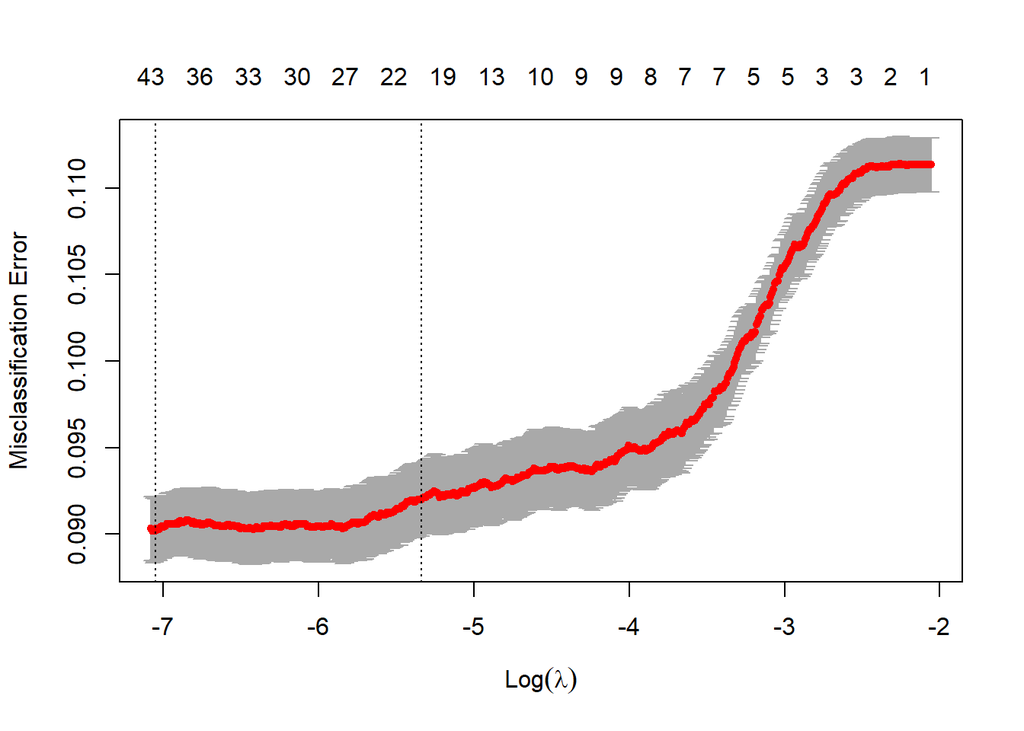

```r
dat.train.x <- model.matrix(y~.,train)
dat.train.y<-as.matrix(train[,24])
cvfit <- cv.glmnet(dat.train.x, dat.train.y, family = "binomial", type.measure = "class", nlambda = 1000)
plot(cvfit)
```

```r
coef(cvfit, s = "lambda.min")
```

```
## 56 x 1 sparse Matrix of class "dgCMatrix"
##                                          1
## (Intercept)                  -4.207121e+01
## (Intercept)                   .
## age                           .
## jobblue-collar               -2.021790e-01
## jobentrepreneur              -1.633144e-02
## jobhousemaid                 -1.480863e-02
## jobmanagement                 .
## jobretired                    1.154413e-01
## jobself-employed             -1.198252e-02
## jobservices                  -1.466821e-01
## jobstudent                    2.341095e-01
## jobtechnician                 3.873314e-02
## jobunemployed                 .
## maritalmarried                .
## maritalsingle                 3.694940e-02
## educationbasic.6y             2.719654e-02
## educationbasic.9y            -2.131391e-02
## educationhigh.school          .
## educationilliterate           1.257055e+00
## educationprofessional.course  .
## educationuniversity.degree    1.000798e-01
## defaultunknown               -2.729949e-01
## housingyes                    .
## loanyes                       .
## contacttelephone             -3.621510e-01
## monthaug                      3.138102e-01
## monthdec                     -7.597149e-02
## monthjul                      1.880086e-01
## monthjun                      6.402111e-02
## monthmar                      1.685199e+00
## monthmay                     -6.424520e-01
## monthnov                     -2.876171e-01
## monthoct                      6.945301e-02
## monthsep                     -1.093432e-01
## day_of_weekmon               -1.036189e-01
## day_of_weekthu                .
## day_of_weektue                8.624198e-03
## day_of_weekwed                2.008579e-02
## duration                      2.521093e-03
## campaign                     -2.739075e-02
## pdays                        -7.487669e-04
## previous                      .
## poutcomenonexistent           4.012496e-01
## poutcomesuccess               1.112954e+00
## emp_var_rate                 -6.018043e-01
## cons_price_idx                6.946629e-01
## cons_conf_idx                 2.896983e-02
## euribor3m                     .
## nr_employed                  -4.849376e-03
## Age_Grp32-37                 -9.618446e-02
## Age_Grp38-47                 -2.050658e-01
## Age_Grp47-55                 -5.124525e-02
## Age_Grp>55                    .
## prevly_CntctdYes              5.751142e-04
## duration_group5-10min         1.038409e+00
## duration_group10+ min         1.921510e+00
```

```r
#CV misclassification error rate is little below .1

print("CV Error Rate:")
```

```
## [1] "CV Error Rate:"
```

```r
cvfit$cvm[which(cvfit$lambda==cvfit$lambda.min)]
```

```
## [1] 0.09021672
```

```r
#"CV Error Rate:"
#0.09021672

#Optimal penalty
print("Penalty Value:")
```

```
## [1] "Penalty Value:"
```

```r
cvfit$lambda.min
```

```
## [1] 0.0008648178
```

```r
#"Penalty Value:"
#0.0008648178

finalmodel<-glmnet(dat.train.x, dat.train.y, family = "binomial",lambda=cvfit$lambda.min)
finalmodel$call
```

```
## glmnet(x = dat.train.x, y = dat.train.y, family = "binomial",
##     lambda = cvfit$lambda.min)
```

```r
finalmodel
```

```
##
## Call:  glmnet(x = dat.train.x, y = dat.train.y, family = "binomial",      lambda = cvfit$lambda.min)
##
##   Df  %Dev    Lambda
## 1 41 42.01 0.0008648
```

```r
dat.test.x<-model.matrix(y~.,test)
fit.pred.lasso <- predict(finalmodel, newx = dat.test.x, type = "response")
test$y[1:15]
```

```
##  [1] yes yes yes yes yes yes yes yes yes yes yes yes yes yes yes
## Levels: no yes
```

```r
fit.pred.lasso[1:15]
```

```
##  [1] 0.51648436 0.17875067 0.75496908 0.24614855 0.02907491 0.21843403
##  [7] 0.05749881 0.03117035 0.21369006 0.16038986 0.17173557 0.35568869
## [13] 0.15018552 0.20535766 0.38774722
```

```r
#confusion matrix at 0.5 cutoff
class.lasso1<-factor(ifelse(fit.pred.lasso>0.5,"yes","no"),levels=c("no","yes"))
# use caret and compute a confusion matrix
confusionMatrix(class.lasso1,test$y, positive = "yes")
```

```
## Confusion Matrix and Statistics
##
##           Reference
## Prediction   no  yes
##        no  6615  464
##        yes  182  388
##
##                Accuracy : 0.9155
##                  95% CI : (0.9091, 0.9217)
##     No Information Rate : 0.8886
##     P-Value [Acc > NIR] : 4.309e-15
##
##                   Kappa : 0.5012
##
##  Mcnemar's Test P-Value : < 2.2e-16
##
##             Sensitivity : 0.45540
##             Specificity : 0.97322
##          Pos Pred Value : 0.68070
##          Neg Pred Value : 0.93445
##              Prevalence : 0.11139
##          Detection Rate : 0.05073
##    Detection Prevalence : 0.07452
##       Balanced Accuracy : 0.71431
##
##        'Positive' Class : yes
##
```